# Indtroduction

Author: Chao Lu, cl1486

**Text dataset: cleaned_twitter_withLabel.csv**

Label:

```
"nft": NFT-related tweets
"Capflow": Market-Quotes-related tweets
"ethereum": ETH-related tweets
"bitcoin": BTC-related tweets
```

# Packages

```python
import pandas as pd
import numpy as np
import matplotlib.pyplot as plt
import seaborn as sns

from wordcloud import WordCloud
from sklearn.feature_extraction.text import TfidfVectorizer,CountVectorizer

import re
from nltk.stem import PorterStemmer

from sklearn.model_selection import  train_test_split
from sklearn.naive_bayes import MultinomialNB
from sklearn.metrics import confusion_matrix,classification_report,accuracy_score,f1_score,roc_auc_score
from sklearn.model_selection import GridSearchCV
from sklearn import svm
```

```python
import warnings

warnings.filterwarnings("ignore")
```

# Naive Bayes

## Data

```python
ori_data = pd.read_csv('cleaned_twitter_withLabel.csv',
                       encoding='utf8',
                       index_col=0,
                       nrows=500)  # ,nrows=99

ori_data.head()
```

|  | topic | text |
| --- | --- | --- |
| 0 | nft | fishytankgame best project congratulation team... |
| 1 | nft | fishytankgame game busy greet project playtoea... |
| 2 | nft | fishytankgame great excellent project thanhlua... |
| 3 | nft | fishytankgame token boom recommend crypto frie... |
| 4 | bitcoin | lorren find bitcoin green vault location join ... |

```python
ori_data.shape
```

```
(500, 2)
```

## EDA and data cleaning

### WordCloud

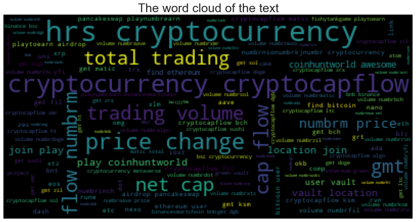

```python
text = ori_data['text'].str.cat()

stop_words = ['numbr','https','co']

wordcloud = WordCloud(min_word_length = 2,max_words = 200,stopwords=stop_words).generate(text)
fig = plt.figure(figsize=(15,10))
plt.imshow(wordcloud)
plt.axis("off")
plt.title('The word cloud of the text',fontsize = 25)
fig.savefig('WordCloud.png')
```

### Stop words

```python
A_STEMMER=PorterStemmer()
def MY_STEMMER(str_input):
    words = re.sub(r"[^A-Za-z\-]", " ", str_input).lower().split()
    words = [A_STEMMER.stem(word) for word in words]
    return words
```

### Data Vectorizeration

```python
### Tf-idf vectorizer
MyTfidf=TfidfVectorizer(input='content',
                        stop_words='english',
                        # max_features=200,
                        tokenizer=MY_STEMMER,
                        lowercase=True
                        )
```

### Crap words

```python
text = ori_data['text']

Tfidf_data=MyTfidf.fit_transform(text)
DF_tfidf=pd.DataFrame(Tfidf_data.toarray(),columns=MyTfidf.get_feature_names())

stop_words = ['t','lqcijjjfmb','mfjqshwoso','s','denjytsey']
DF_tfidf = DF_tfidf.drop(stop_words,axis = 1)
DF_tfidf['label'] = ori_data['topic']
```

### Train test split

```python
# tfidf
TrainDF, TestDF = train_test_split(DF_tfidf,test_size = 0.3,random_state=2)

train_data = TrainDF.iloc[:,:-1]
train_label = TrainDF['label']

test_data = TestDF.iloc[:,:-1]
test_label = TestDF['label']
```

## Model training

### Model training

```python
# initialize the model
MyModelNB= MultinomialNB()

X_train = train_data
y_train = train_label
MyModelNB.fit(X_train, y_train)
MyModelNB.get_params()
```

```
{'alpha': 1.0, 'class_prior': None, 'fit_prior': True}
```

### Discussion on model

The model just applied the default parameters, including "alpha",'class_prior','fit_prior' bascially.

The multinomial Naive Bayes classifier is suitable for classification with discrete features (e.g., word counts for text classification). The multinomial distribution normally requires integer feature counts. However, in practice, fractional counts such as tf-idf may also work.

### Confusion matrix and accuracy report

```python
MULNB_pred = MyModelNB.predict(test_data)
MULNB_pred_prob = MyModelNB.predict_proba(test_data)

labels=y_train.unique()

conf_mat = pd.DataFrame(confusion_matrix(test_label,MULNB_pred),index=labels,columns=labels)
conf_mat
```

[output not shown]

[figure not shown]

```python
plt.figure(figsize = (10,7))
sns.heatmap(conf_mat, annot=True, cmap="YlGnBu")
plt.show()
```

```python
multiNB_ACC = accuracy_score(test_label, MULNB_pred)
multiNB_f1 = f1_score(test_label, MULNB_pred, average='micro')
multiNB_roc_auc = roc_auc_score(test_label,MULNB_pred_prob, multi_class='ovr')


print("Roc score:",multiNB_roc_auc)
print("F1 score:",multiNB_f1)
print("ACC:",multiNB_ACC)
print(classification_report(test_label, MULNB_pred))
```

```
Roc score: 1.0
F1 score: 0.9733333333333334
ACC: 0.9733333333333334
              precision    recall  f1-score   support

     Capflow       1.00      1.00      1.00       129
     bitcoin       1.00      0.43      0.60         7
    ethereum       0.67      1.00      0.80         8
         nft       1.00      1.00      1.00         6

    accuracy                           0.97       150
   macro avg       0.92      0.86      0.85       150
weighted avg       0.98      0.97      0.97       150
```

### Discussion on the result

Due to the imbalance of the dataset, the accuracy of the prediction in this model is pretty high. However, the imbalance is exactly the main reason causing this high performance. Since most of the data is classified into "Capflow", therefore, the mode will be more sensitive to the "Capflow".

However, to solve this problem, the "Accuracy" should not be our main indicator to measure the model but recall and f1 score.

## Conclusion

**Naive Bayes can achieve a pretty good performance in classifying the tweets.**

As a matural model, Multinominal naive Bayes is pretty good to help recognize and classify the text content. However, there is also a deficiency in this project, where the project just used the default param, like alpha. A better result could be achieved if tuning the parameter using some advanced method, like "Grid search".

# SVM

## Linear Kernel

### Model training

```python
parameters = {'C':np.linspace(0.1,10,10)}

svc = svm.SVC(kernel='linear',probability=True)

clf_L = GridSearchCV(svc, parameters)

%time
clf_L.fit(X_train, y_train)
```

```
CPU times: user 5 µs, sys: 2 µs, total: 7 µs
Wall time: 16.9 µs
```

```
GridSearchCV(estimator=SVC(kernel='linear', probability=True),
             param_grid={'C': array([ 0.1,  1.2,  2.3,  3.4,  4.5,  5.6,  6.7,  7.8,  8.9, 10. ])})
```

### Tuning the parameters

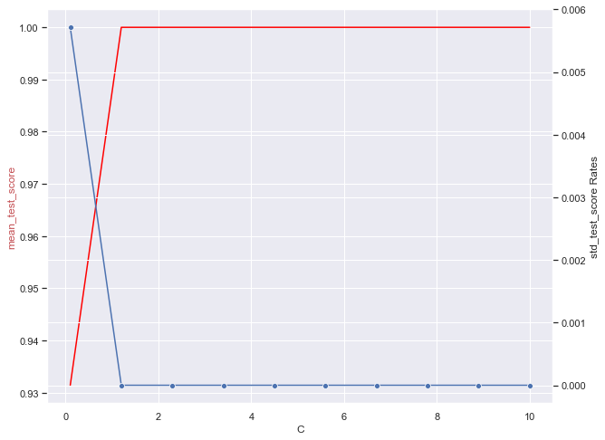

```python
mean_score = clf_L.cv_results_['mean_test_score']
std_score = clf_L.cv_results_['std_test_score']
x = parameters['C']

fig, ax1 = plt.subplots(figsize = (10,8))
sns.set_theme()

ax2 = ax1.twinx()
sns.lineplot(x = x, y = mean_score, ax = ax1,color = 'red')
sns.lineplot(x = x, y = std_score, marker = 'o', ax = ax2)

# these lines add the annotations for the plot.
ax1.set_xlabel('C')
ax1.set_ylabel('mean_test_score',c = "r")
ax2.set_ylabel('std_test_score Rates')

plt.show(); # shows the plot.
```

### Confusion matrix

```python
pred = clf_L.predict(test_data)
labels=y_train.unique()

conf_mat = pd.DataFrame(confusion_matrix(test_label,pred),index=labels,columns=labels)
plt.figure(figsize = (10,7))
sns.heatmap(conf_mat, annot=True, cmap="YlGnBu")
plt.show()
```

[output not shown]

## poly kernel

### Model training

```python
parameters = {'degree':range(10)}

svc = svm.SVC(kernel='poly')

clf_P = GridSearchCV(svc, parameters)

%time
clf_P.fit(X_train, y_train)
```

```
CPU times: user 6 µs, sys: 2 µs, total: 8 µs
Wall time: 19.1 µs
```

```
GridSearchCV(estimator=SVC(kernel='poly'), param_grid={'degree': range(0, 10)})
```

### Tuning the parameters

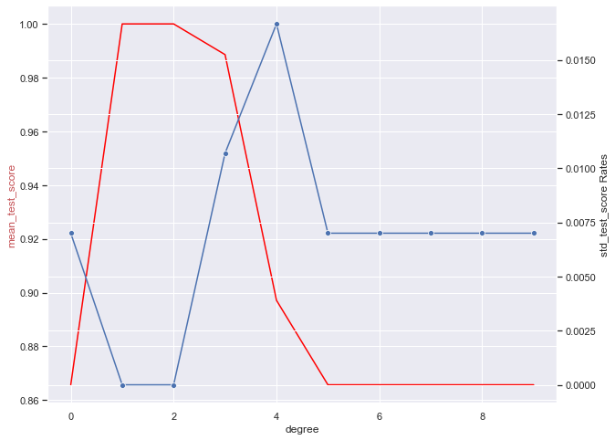

```python
mean_score = clf_P.cv_results_['mean_test_score']
std_score = clf_P.cv_results_['std_test_score']
x = parameters['degree']

fig, ax1 = plt.subplots(figsize = (10,8))
sns.set_theme()

ax2 = ax1.twinx()
sns.lineplot(x = x, y = mean_score, ax = ax1,color = 'red')
sns.lineplot(x = x, y = std_score, marker = 'o', ax = ax2)

# these lines add the annotations for the plot.
ax1.set_xlabel('degree')
ax1.set_ylabel('mean_test_score',c = "r")
ax2.set_ylabel('std_test_score Rates')

plt.show(); # shows the plot.
```

### Confusion matrix

```python
pred = clf_P.predict(test_data)
labels=y_train.unique()

conf_mat = pd.DataFrame(confusion_matrix(test_label,pred),index=labels,columns=labels)
plt.figure(figsize = (10,7))
sns.heatmap(conf_mat, annot=True, cmap="YlGnBu")
plt.show()
```

[output not shown]

## rbf kernel

### Model training

```python
parameters = {'gamma':np.linspace(0.01,10,10)}

svc = svm.SVC(kernel='rbf',probability=True)

clf_R = GridSearchCV(svc, parameters)

%time
clf_R.fit(X_train, y_train)
```

```
CPU times: user 5 µs, sys: 1 µs, total: 6 µs
Wall time: 23.8 µs
```

```
GridSearchCV(estimator=SVC(probability=True),
             param_grid={'gamma': array([ 0.01,  1.12,  2.23,  3.34,  4.45,  5.56,  6.67,  7.78,  8.89,
       10.  ])})
```

### Tuning the parameters

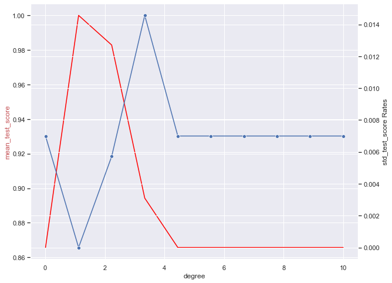

```python
mean_score = clf_R.cv_results_['mean_test_score']
std_score = clf_R.cv_results_['std_test_score']
x = parameters['gamma']

fig, ax1 = plt.subplots(figsize = (10,8))
sns.set_theme()

ax2 = ax1.twinx()
sns.lineplot(x = x, y = mean_score, ax = ax1,color = 'red')
sns.lineplot(x = x, y = std_score, marker = 'o', ax = ax2)

# these lines add the annotations for the plot.
ax1.set_xlabel('degree')
ax1.set_ylabel('mean_test_score',c = "r")
ax2.set_ylabel('std_test_score Rates')

plt.show(); # shows the plot.
```

### Confusion matrix

```python
pred = clf_R.predict(test_data)
labels=y_train.unique()

conf_mat = pd.DataFrame(confusion_matrix(test_label,pred),index=labels,columns=labels)
plt.figure(figsize = (10,7))
sns.heatmap(conf_mat, annot=True, cmap="YlGnBu")
plt.show()
```

[output not shown]

# Conlcuison

**SVMs takes high accuracy the expense of dataset limitations**

Traditionally, SVMs do not perform well on highly skewed/imbalanced data sets. These are training data sets in which the number of samples that fall in one of the classes far outnumbers those that are a member of the other class.

However, due to the highly convincing mathematical support behind the SVM, it could achieve an ideal accuracy once the conditions are set.